# Explanatory Data Analysis(EDA) with Python for Beginners

I'm doing an EDA of StudentsPerformance dataset in latest version(October 3,2020) of jupyter notebook. You can download the dataset from [here](https://www.kaggle.com/spscientist/students-performance-in-exams). I have Anoconda Navigator that lets you access applications like Jupyter Notebook, Spyder, PyCharm, RStudio and many more (you can read more about Anoconda Navigator [here](https://docs.anaconda.com/anaconda/navigator/)). Download Anoconda Navigator from [here](https://www.anaconda.com/products/individual).

**If you find this notebook helpful please upvote.**

### Importing required libraries

You can read about them in detail from the links given.

- [panda](http://www.geeksforgeeks.org/python-data-analysis-using-pandas/)
- [numpy](https://www.tutorialspoint.com/numpy/index.htm)
- [matplotlib](https://www.datacamp.com/community/tutorials/matplotlib-tutorial-python)
- [seaborn](https://seaborn.pydata.org/).

Most of these sites have information on all the popular python libraries so, you can choose from which site you understand the topic most and search other librarys in them.

```python
import pandas as pd    # for data analysis
import numpy as np     # to work with array
import matplotlib.pyplot as plt  # used for visualization
import seaborn as sns            # based on matplotlib provides more features for visualization
%matplotlib inline

import os
```

%matplotlib inline used for for embedding the plot in notebook

# Loading and preprocessing the dataset

Now let's read the csv file and store it into a DataFrame

```python
StudentsPerformance = pd.read_csv("StudentsPerformance.csv")
```

```python
StudentsPerformance #lets display our dataset
```

|  | gender | race/ethnicity | parental level of education | lunch | test preparation course | math score | reading score | writing score |
| --- | --- | --- | --- | --- | --- | --- | --- | --- |
| 0 | female | group B | bachelor's degree | standard | none | 72 | 72 | 74 |
| 1 | female | group C | some college | standard | completed | 69 | 90 | 88 |
| 2 | female | group B | master's degree | standard | none | 90 | 95 | 93 |
| 3 | male | group A | associate's degree | free/reduced | none | 47 | 57 | 44 |
| 4 | male | group C | some college | standard | none | 76 | 78 | 75 |
| ... | ... | ... | ... | ... | ... | ... | ... | ... |
| 995 | female | group E | master's degree | standard | completed | 88 | 99 | 95 |
| 996 | male | group C | high school | free/reduced | none | 62 | 55 | 55 |
| 997 | female | group C | high school | free/reduced | completed | 59 | 71 | 65 |
| 998 | female | group D | some college | standard | completed | 68 | 78 | 77 |
| 999 | female | group D | some college | free/reduced | none | 77 | 86 | 86 |

1000 rows × 8 columns

```python
StudentsPerformance.columns  #displaying columns
```

```
Index(['gender', 'race/ethnicity', 'parental level of education', 'lunch',
       'test preparation course', 'math score', 'reading score',
       'writing score'],
      dtype='object')
```

```python
StudentsPerformance.head(5) #displaying the top 5 rows
```

|  | gender | race/ethnicity | parental level of education | lunch | test preparation course | math score | reading score | writing score |
| --- | --- | --- | --- | --- | --- | --- | --- | --- |
| 0 | female | group B | bachelor's degree | standard | none | 72 | 72 | 74 |
| 1 | female | group C | some college | standard | completed | 69 | 90 | 88 |
| 2 | female | group B | master's degree | standard | none | 90 | 95 | 93 |
| 3 | male | group A | associate's degree | free/reduced | none | 47 | 57 | 44 |
| 4 | male | group C | some college | standard | none | 76 | 78 | 75 |

```python
StudentsPerformance.describe() #providing the statistical overview of all the numerical columns in our dataset
```

|  | math score | reading score | writing score |
| --- | --- | --- | --- |
| count | 1000.00000 | 1000.000000 | 1000.000000 |
| mean | 66.08900 | 69.169000 | 68.054000 |
| std | 15.16308 | 14.600192 | 15.195657 |
| min | 0.00000 | 17.000000 | 10.000000 |
| 25% | 57.00000 | 59.000000 | 57.750000 |
| 50% | 66.00000 | 70.000000 | 69.000000 |
| 75% | 77.00000 | 79.000000 | 79.000000 |
| max | 100.00000 | 100.000000 | 100.000000 |

count: values in each column

mean: average of values in each column

std: standard deviation

min: minimum value in each column

25%: 25% values will fall under the given value(like for math score 25% values will be less than or equals to 57.0)

50%: 50% values will fall under the given value

75%: 75% values will fall under the given value

max: maximum value in each column

##### We can also use describe function on individual column

```python
StudentsPerformance['race/ethnicity'].describe() #describing race/ethnicity column
```

```
count        1000
unique          5
top       group C
freq          319
Name: race/ethnicity, dtype: object
```

```python
StudentsPerformance.sample(5) #five random rows from the dataset, helpful to get an idea about our dataset
```

|  | gender | race/ethnicity | parental level of education | lunch | test preparation course | math score | reading score | writing score |
| --- | --- | --- | --- | --- | --- | --- | --- | --- |
| 558 | female | group B | associate's degree | free/reduced | none | 53 | 70 | 70 |
| 199 | female | group B | bachelor's degree | free/reduced | none | 78 | 79 | 76 |
| 964 | male | group D | some college | standard | none | 72 | 57 | 58 |
| 437 | male | group D | associate's degree | free/reduced | none | 75 | 66 | 73 |
| 981 | male | group D | some high school | standard | none | 81 | 78 | 78 |

```python
StudentsPerformance.isnull().sum() #counting no of null/missing values
```

```
gender                         0
race/ethnicity                 0
parental level of education    0
lunch                          0
test preparation course        0
math score                     0
reading score                  0
writing score                  0
dtype: int64
```

As no null values are present we will analyse the data now. If null values were present we would had to deal with them similar to [this way](https://www.geeksforgeeks.org/working-with-missing-data-in-pandas/).

```python
StudentsPerformance.info() #information about count of values present and their datatype
```

```
<class 'pandas.core.frame.DataFrame'>
RangeIndex: 1000 entries, 0 to 999
Data columns (total 8 columns):
 #   Column                       Non-Null Count  Dtype
---  ------                       --------------  -----
 0   gender                       1000 non-null   object
 1   race/ethnicity               1000 non-null   object
 2   parental level of education  1000 non-null   object
 3   lunch                        1000 non-null   object
 4   test preparation course      1000 non-null   object
 5   math score                   1000 non-null   int64
 6   reading score                1000 non-null   int64
 7   writing score                1000 non-null   int64
dtypes: int64(3), object(5)
memory usage: 62.6+ KB
```

```python
#information about data shape
print("No. of rows: {}".format(StudentsPerformance.shape[0]))
print("No. of columns: {}".format(StudentsPerformance.shape[1]))
```

```
No. of rows: 1000
No. of columns: 8
```

### Caluculating percentage

We can make it easier to understand the performance of students by adding another column percentage.

```python
StudentsPerformance['percentage'] = (StudentsPerformance['math score']+StudentsPerformance['reading score'] + StudentsPerformance['writing score'])/3
StudentsPerformance['percentage']=StudentsPerformance.percentage.round(decimals=2) #rounding up the values in percentage to two decimal place
```

```python
StudentsPerformance.sample(10) #viewing ten random rows
```

|  | gender | race/ethnicity | parental level of education | lunch | test preparation course | math score | reading score | writing score | percentage |
| --- | --- | --- | --- | --- | --- | --- | --- | --- | --- |
| 415 | male | group E | high school | standard | none | 84 | 73 | 69 | 75.33 |
| 344 | male | group D | some college | standard | none | 79 | 73 | 67 | 73.00 |
| 62 | male | group A | associate's degree | free/reduced | none | 62 | 61 | 55 | 59.33 |
| 722 | female | group B | some high school | free/reduced | completed | 74 | 90 | 88 | 84.00 |
| 331 | male | group C | associate's degree | standard | none | 47 | 37 | 35 | 39.67 |
| 944 | female | group B | high school | standard | none | 58 | 68 | 61 | 62.33 |
| 319 | female | group D | associate's degree | free/reduced | none | 56 | 65 | 63 | 61.33 |
| 134 | male | group D | bachelor's degree | free/reduced | completed | 74 | 79 | 75 | 76.00 |
| 564 | male | group B | bachelor's degree | free/reduced | none | 48 | 51 | 46 | 48.33 |
| 487 | female | group C | associate's degree | free/reduced | none | 60 | 75 | 74 | 69.67 |

```python
StudentsPerformance['percentage'].describe() #describing percentage column
```

```
count    1000.000000
mean       67.770580
std        14.257311
min         9.000000
25%        58.330000
50%        68.330000
75%        77.670000
max       100.000000
Name: percentage, dtype: float64
```

### Top 10 scorers

we can sort values of a column in descending order by using sort_values function and then by applying head(10) we take the top ten rows and store it in TopTenPrcntgs.

```python
TopTenPrcntgs = StudentsPerformance.sort_values('percentage',ascending=False).head(10)
TopTenPrcntgs #displaying ten rows with highest percentage
```

|  | gender | race/ethnicity | parental level of education | lunch | test preparation course | math score | reading score | writing score | percentage |
| --- | --- | --- | --- | --- | --- | --- | --- | --- | --- |
| 916 | male | group E | bachelor's degree | standard | completed | 100 | 100 | 100 | 100.00 |
| 458 | female | group E | bachelor's degree | standard | none | 100 | 100 | 100 | 100.00 |
| 962 | female | group E | associate's degree | standard | none | 100 | 100 | 100 | 100.00 |
| 114 | female | group E | bachelor's degree | standard | completed | 99 | 100 | 100 | 99.67 |
| 179 | female | group D | some high school | standard | completed | 97 | 100 | 100 | 99.00 |
| 712 | female | group D | some college | standard | none | 98 | 100 | 99 | 99.00 |
| 165 | female | group C | bachelor's degree | standard | completed | 96 | 100 | 100 | 98.67 |
| 625 | male | group D | some college | standard | completed | 100 | 97 | 99 | 98.67 |
| 903 | female | group D | bachelor's degree | free/reduced | completed | 93 | 100 | 100 | 97.67 |
| 149 | male | group E | associate's degree | free/reduced | completed | 100 | 100 | 93 | 97.67 |

### Least 10 scorers

Similarly if we sort the values in ascending order of percentage then the top ten values will be lowest percentages.

```python
BottomTenPrcntgs = StudentsPerformance.sort_values('percentage', ascending=True).head(10)
BottomTenPrcntgs #displaying ten rows with lowest percentage
```

|  | gender | race/ethnicity | parental level of education | lunch | test preparation course | math score | reading score | writing score | percentage |
| --- | --- | --- | --- | --- | --- | --- | --- | --- | --- |
| 59 | female | group C | some high school | free/reduced | none | 0 | 17 | 10 | 9.00 |
| 980 | female | group B | high school | free/reduced | none | 8 | 24 | 23 | 18.33 |
| 596 | male | group B | high school | free/reduced | none | 30 | 24 | 15 | 23.00 |
| 327 | male | group A | some college | free/reduced | none | 28 | 23 | 19 | 23.33 |
| 76 | male | group E | some high school | standard | none | 30 | 26 | 22 | 26.00 |
| 17 | female | group B | some high school | free/reduced | none | 18 | 32 | 28 | 26.00 |
| 601 | female | group C | high school | standard | none | 29 | 29 | 30 | 29.33 |
| 787 | female | group B | some college | standard | none | 19 | 38 | 32 | 29.67 |
| 338 | female | group B | some high school | free/reduced | none | 24 | 38 | 27 | 29.67 |
| 211 | male | group C | some college | free/reduced | none | 35 | 28 | 27 | 30.00 |

```python
StudentsPerformance.gender.value_counts()     # no. of male and female students
```

```
female    518
male      482
Name: gender, dtype: int64
```

```python
StudentsPerformance['race/ethnicity'].value_counts()  # No. of people belonging to each race/ethnicity
```

```
group C    319
group D    262
group B    190
group E    140
group A     89
Name: race/ethnicity, dtype: int64
```

# Statistical Data Analysis

Now let's perform some statistical operations on the dataset.

```python
StudentsPerformance.mean() #Calculating mean of each column with numeric value
```

```
math score       66.08900
reading score    69.16900
writing score    68.05400
percentage       67.77058
dtype: float64
```

We can see that the average score of math test is 66.09, reading test is 69.17, writing test is 68.05, percentage is 67.77. So we can say that the students performed better in reading test. And the school needs to pay more attention to math subject.

### Using groupby for storing mean of marks w.r.t. various attributes

#### Storing mean of marks and percentage w.r.t. gender and displaying then in descending order

```python
gender_details = StudentsPerformance.groupby('gender')[['math score','reading score', 'writing score','percentage']].mean()
gender_details.sort_values('percentage',ascending=False)
```

| gender | math score | reading score | writing score | percentage |
| --- | --- | --- | --- | --- |
| female | 63.633205 | 72.608108 | 72.467181 | 69.569498 |
| male | 68.728216 | 65.473029 | 63.311203 | 65.837303 |

#### Storing mean of marks and percentage w.r.t. parental level of education and displaying then in decending order

```python
parental_lvl_of_edu_details = StudentsPerformance.groupby('parental level of education')[['math score','writing score','reading score','percentage']].mean()
parental_lvl_of_edu_details.sort_values('percentage',ascending=False)
```

| parental level of education | math score | writing score | reading score | percentage |
| --- | --- | --- | --- | --- |
| master's degree | 69.745763 | 75.677966 | 75.372881 | 73.598644 |
| bachelor's degree | 69.389831 | 73.381356 | 73.000000 | 71.923983 |
| associate's degree | 67.882883 | 69.896396 | 70.927928 | 69.568964 |
| some college | 67.128319 | 68.840708 | 69.460177 | 68.476106 |
| some high school | 63.497207 | 64.888268 | 66.938547 | 65.107654 |
| high school | 62.137755 | 62.448980 | 64.704082 | 63.097194 |

#### Storing mean of marks and percentage w.r.t. lunch and displaying then in decending order

```python
lunch_details = StudentsPerformance.groupby('lunch')[['math score','writing score','reading score','percentage']].mean()
lunch_details.sort_values('percentage',ascending=False)
```

| lunch | math score | writing score | reading score | percentage |
| --- | --- | --- | --- | --- |
| standard | 70.034109 | 70.823256 | 71.654264 | 70.837116 |
| free/reduced | 58.921127 | 63.022535 | 64.653521 | 62.198986 |

## Visualizing Data

Visualizing data is nothing but representing data in form of graphs. Visualization is generally done to infer some new information or pattern from the data as we understand more from graphical representation. Many times the data is too big like a csv file may contain hundreds or even thousands of records and so, infering new information by just looking at the raw data might not be possible hence we perform operations on the data like data visualization to find hidden patterns and information.

### Now let's plot some random graphs

```python
sns.set_style("whitegrid") #set theme to whitegrid
```

Scatter plot with math score as x-axis,writing score as y-axis and color them by type of lunch they have. Read more here about [scatter plot](https://seaborn.pydata.org/generated/seaborn.scatterplot.html).

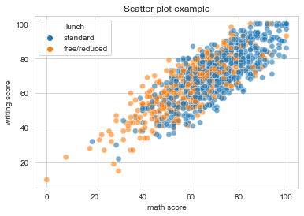

```python
sns.scatterplot(x='math score',y='writing score',data=StudentsPerformance, hue= 'lunch',alpha=0.6,s=50); # alpha defines opacity and s defines size of the dots, you can play change them.
plt.title("Scatter plot example"); #giving title to graph
#we didn't need to provide label for x and y axis in seaborn
```

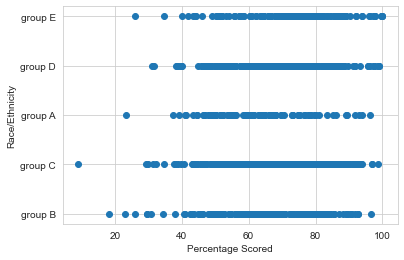

```python
#using matplotlib to plot scatter plot
fig, ax=plt.subplots() # plt.subplots() return tuple containing figure and axes object that are stored in fig and ax.

ax.scatter(StudentsPerformance['percentage'],StudentsPerformance['race/ethnicity']);
plt.xlabel('Percentage Scored');
plt.ylabel('Race/Ethnicity');
```

#### Plotting two histogram together to compare their data.

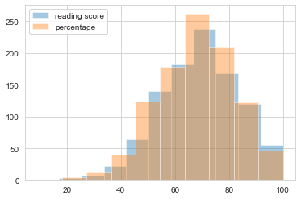

```python
plt.hist(StudentsPerformance['reading score'],alpha=0.4);
plt.hist(StudentsPerformance.percentage,alpha=0.4);
plt.legend(['reading score','percentage']);
```

#### Plotting a simple bar graph showing us how many parents have what level of education.

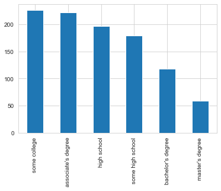

```python
StudentsPerformance['parental level of education'].value_counts().plot(kind='bar');
```

#### Pie plot

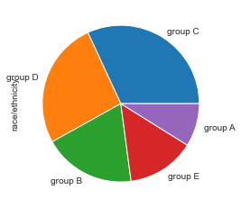

```python
StudentsPerformance['race/ethnicity'].value_counts().plot(kind='pie');
```

### Pair plot with seaborn

Seaborn gives us the functionality to automatically plot different graphs from a dataset

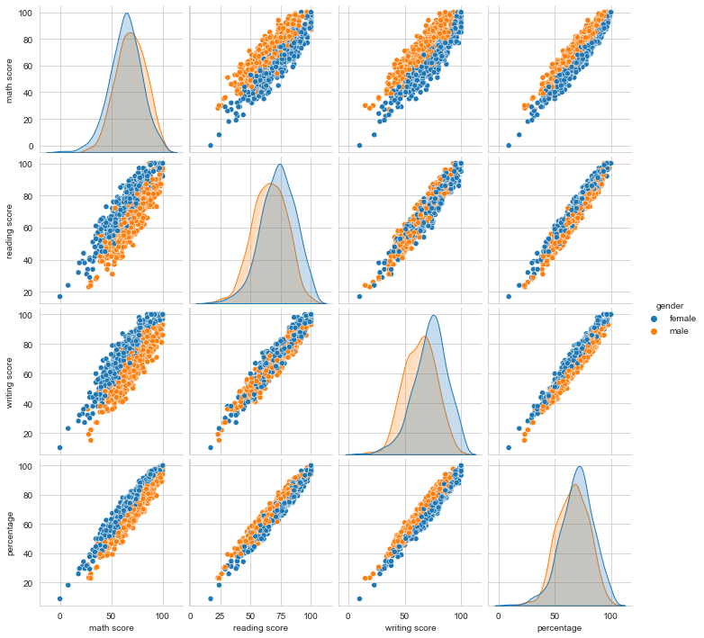

```python
sns.pairplot(StudentsPerformance, hue='gender');
```

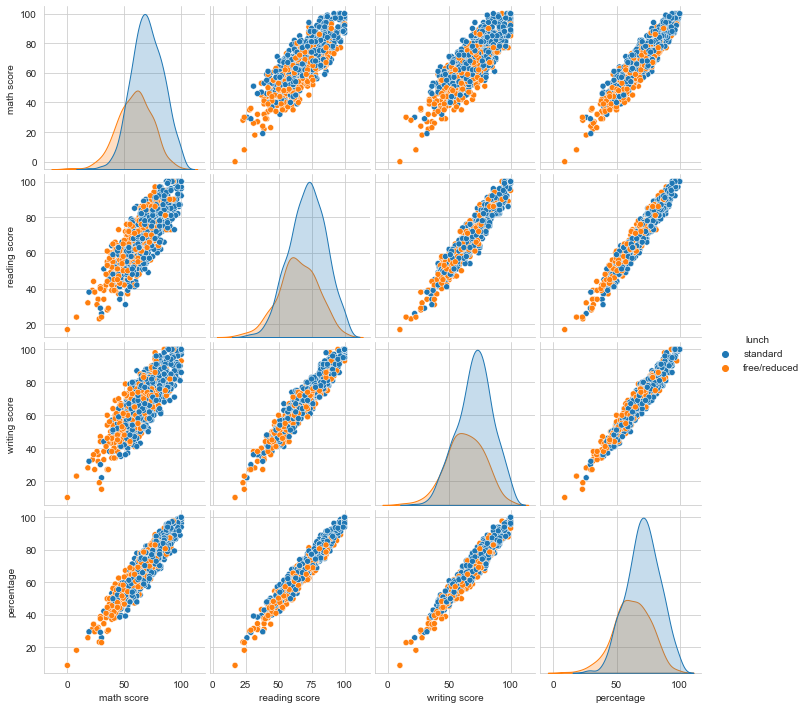

```python
sns.pairplot(StudentsPerformance,hue='lunch');
```

# Explanatory Data Analysis (EDA)

### 1. What is the range of score for majority of students?

#### Plotting stacked histogram

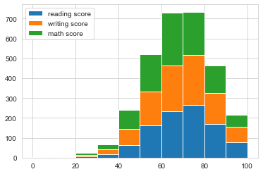

```python
plt.hist([StudentsPerformance['reading score'],StudentsPerformance['writing score'],StudentsPerformance['math score']], stacked=True);
plt.legend(['reading score','writing score','math score']);
```

Stacked bar graph puts the new segment on top of the current segment. Here we can use it to see the total marks scored by students. We can also infer that most students scored between 60-80 marks in there tests.

### 2. From which group do students score better?

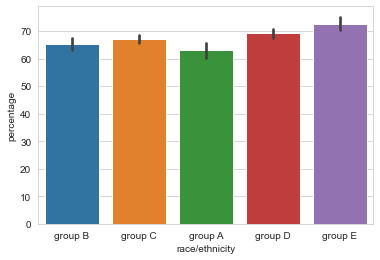

```python
sns.barplot(x='race/ethnicity',y='percentage', data=StudentsPerformance);
```

We can see that students from group E scored the most then group D then group c then group B then group A.

### 3. Which gender performed better overall?

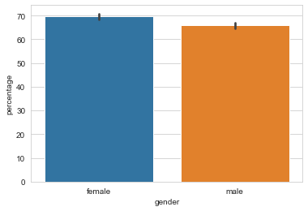

```python
sns.barplot(x='gender',y='percentage', data=StudentsPerformance);
```

Girls performed better then boys

### 4. Does lunch impacts students performance?

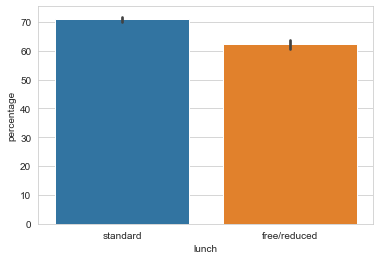

```python
sns.barplot(x='lunch',y='percentage',data=StudentsPerformance);
```

Yes students which were provided standard lunch performed better then students with free/reduced lunch

### 5. Do students perform better if they complete their test prepration?

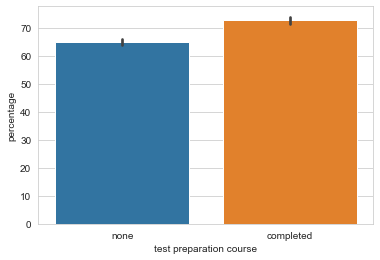

```python
sns.barplot(x='test preparation course',y='percentage',data=StudentsPerformance);
```

Yes students who complete their test preparation course perform better then students who do not complete it.

### 6. Does parents education impact their childs performance?

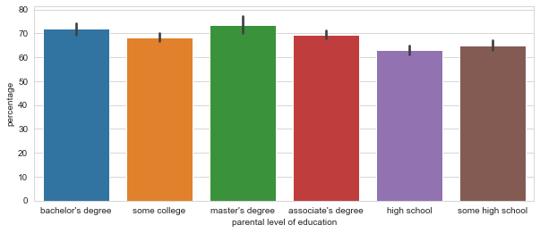

```python
plt.figure(figsize=(10,4)); #define figure size
sns.barplot(x='parental level of education',y='percentage',data=StudentsPerformance);
```

As we can see the data shows that parents education does impact students performance.

## Summary

For future we could compare data from different countries to see how the students perform in developed and developing countries, is there any difference if so then how can the performance be improved.

From the given dataset StudentPerformance we can see that the performance of students depends on various factors like some of the attributes mentioned above. We could clearly see correlation between students performance and amenities provided to him.